# Report 2

Advay Vyas

January 23, 2026

# Introduction

This week, I will further investigate Frechet distance and dynamic time warping and try to develop an intuition or way to discern differences between state and local forecasting levels through an examination of the plots of these two metrics. Also, I’ll investigate Shannon entropy. Lastly, I’ll take a look through a few forecasting models from FluSight (the dashboard) and then try to find some good models.

## Data processing

```r
hsa_state = read.csv("../hsa_state_inc.csv")
```

# Metric intuition

## Metric functions

```r
discrete_frechet = function(P, Q, dist_fun = NULL) {
    # P: n x d matrix or data.frame Q: m x d matrix or
    # data.frame dist_fun: function(x, y) returning scalar
    # distance

    if (is.null(dist_fun)) {
        dist_fun = function(x, y) sqrt(sum((x - y)^2))
    }

    P = as.matrix(P)
    Q = as.matrix(Q)

    n = nrow(P)
    m = nrow(Q)

    # distance matrix
    dist_mat = matrix(0, n, m)
    for (i in 1:n) for (j in 1:m) dist_mat[i, j] = dist_fun(P[i,
        ], Q[j, ])

    # DP table
    D = matrix(Inf, n, m)
    Prev = array(NA_integer_, dim = c(n, m, 2))

    # initialization
    D[1, 1] = dist_mat[1, 1]

    for (i in 2:n) {
        D[i, 1] = max(D[i - 1, 1], dist_mat[i, 1])
        Prev[i, 1, ] = c(i - 1, 1)
    }

    for (j in 2:m) {
        D[1, j] = max(D[1, j - 1], dist_mat[1, j])
        Prev[1, j, ] = c(1, j - 1)
    }

    # DP recursion
    for (i in 2:n) {
        for (j in 2:m) {
            candidates = c(D[i - 1, j], D[i, j - 1], D[i - 1,
                j - 1])

            k = which.min(candidates)

            if (k == 1)
                Prev[i, j, ] = c(i - 1, j)
            if (k == 2)
                Prev[i, j, ] = c(i, j - 1)
            if (k == 3)
                Prev[i, j, ] = c(i - 1, j - 1)

            D[i, j] = max(dist_mat[i, j], candidates[k])
        }
    }

    # backtrack optimal path
    i = n
    j = m
    path = matrix(c(i, j), ncol = 2)

    while (!(i == 1 && j == 1)) {
        p = Prev[i, j, ]
        i = p[1]
        j = p[2]
        path = rbind(c(i, j), path)
    }

    # stepwise Frechet values
    step_dist = apply(path, 1, function(idx) dist_mat[idx[1],
        idx[2]])

    frechet_steps = cummax(step_dist)

    list(frechet = D[n, m], path = path, step_distance = step_dist,
        frechet_by_step = frechet_steps)
}

dtw_distance = function(P, Q, dist_fun = NULL) {
    # P, Q: numeric vectors or matrices (rows = time
    # points)
    if (is.null(dist_fun))
        dist_fun = function(x, y) sqrt(sum((x - y)^2))

    P = as.matrix(P)
    Q = as.matrix(Q)

    n = nrow(P)
    m = nrow(Q)

    # distance matrix
    dist_mat = matrix(0, n, m)
    for (i in 1:n) for (j in 1:m) dist_mat[i, j] = dist_fun(P[i,
        ], Q[j, ])

    # cumulative cost matrix
    D = matrix(Inf, n, m)
    D[1, 1] = dist_mat[1, 1]

    # initialize first row/column
    for (i in 2:n) D[i, 1] = dist_mat[i, 1] + D[i - 1, 1]
    for (j in 2:m) D[1, j] = dist_mat[1, j] + D[1, j - 1]

    # fill rest of matrix
    for (i in 2:n) {
        for (j in 2:m) {
            D[i, j] = dist_mat[i, j] + min(D[i - 1, j], D[i,
                j - 1], D[i - 1, j - 1])
        }
    }

    # backtrack optimal path
    i = n
    j = m
    path = matrix(c(i, j), ncol = 2)
    while (!(i == 1 && j == 1)) {
        if (i == 1) {
            j = j - 1
        } else if (j == 1) {
            i = i - 1
        } else {
            # choose minimum predecessor
            k = which.min(c(D[i - 1, j - 1], D[i - 1, j], D[i,
                j - 1]))
            if (k == 1) {
                i = i - 1
                j = j - 1
            } else if (k == 2) {
                i = i - 1
            } else {
                j = j - 1
            }
        }
        path = rbind(c(i, j), path)
    }

    # stepwise cumulative cost along path
    step_cost = dist_mat[path]
    cum_cost = cumsum(step_cost)

    list(dtw_distance = D[n, m], path = path, step_cost = step_cost,
        cum_cost = cum_cost)
}
```

We convert into matrices and run the code and find this graph as the DTW/step.

```r
graph_hsa = function(hsa_id = 688) {
    hsa = hsa_state[hsa_state$hsa_nci_id == hsa_id, ]

    P = as.matrix(hsa$inc_hsa)
    Q = as.matrix(hsa$inc_state)

    res_dtw = dtw_distance(P, Q)

    res = discrete_frechet(P, Q)

    normal = ggplot(hsa) + geom_line(linewidth = 1, (aes(x = seq_len(148),
        y = inc_hsa, color = "HSA"))) + geom_line(linewidth = 1,
        (aes(x = seq_len(148), y = inc_state, color = "State"))) +
        labs(x = "index (weeks, 2022 Week 39 to 2025 Week 30)",
            y = "infected_value (?)", title = paste0("Local vs. state inc values for HSA ID ",
                hsa_id, " from ", hsa$state)) + theme_minimal() +
        scale_color_manual(name = "Legend", values = c(HSA = "blue",
            State = "red"))

    frechet = ggplot() + geom_line(aes(x = seq_len(length(res$frechet_by_step)),
        y = res$frechet_by_step), linewidth = 1) + theme_minimal() +
        labs(x = "Steps", y = "Frechet distance", title = "Frechet distance by step")

    dtw = ggplot() + geom_line(aes(x = seq_len(length(res_dtw$cum_cost)),
        y = res_dtw$cum_cost), linewidth = 1) + theme_minimal() +
        labs(x = "Steps", y = "Cumulative DTW cost", title = "DTW cumulative cost along optimal path by step")

    # dtw adjusted
    P_warped = rep(NA, length(Q))
    i = res_dtw$path[, 1]
    j = res_dtw$path[, 2]
    P_warped[j] = P[i]
    # P_warped = na.approx(P_warped, rule = 2)

    df_plot = data.frame(index = seq_len(length(Q)), HSA_aligned = P_warped,
        State = Q)

    warped = ggplot(df_plot) + geom_line(aes(x = index, y = HSA_aligned,
        color = "HSA (warped)"), linewidth = 1) + geom_line(aes(x = index,
        y = State, color = "State"), linewidth = 1) + labs(x = "index (weeks, 2022 Week 39 to 2025 Week 30)",
        y = "infected_value (?)", title = paste0("DTW-aligned Local vs. state inc values for HSA ID ",
            hsa_id, " from ", hsa$state)) + theme_minimal() +
        scale_color_manual(name = "Legend", values = c(`HSA (warped)` = "blue",
            State = "red"))

    (normal/warped)/(frechet + dtw)
}
```

## Intrepreting DTW

From the path variable in res_dtw, we can create and understand several timing distortion statistics. The first one is $\Delta t$, which is the local time shift for each time index. Basically, what time steps in HSA are matched to which time step in state. Therefore, positive means state lags, and negative means state leads.

```r
dtw_stats = function(hsa_id = 688) {
    hsa = hsa_state[hsa_state$hsa_nci_id == hsa_id, ]

    P = as.matrix(hsa$inc_hsa)
    Q = as.matrix(hsa$inc_state)

    res_dtw = dtw_distance(P, Q)

    res = discrete_frechet(P, Q)

    i = res_dtw$path[, 1]
    j = res_dtw$path[, 2]

    delta_t = j - i
    delta_x = P[i, 1] - Q[j, 1]

    stats_list = list(mean_abs_lag = mean(abs(delta_t)), signed_lag = mean(delta_t),
        lag_sd = sd(delta_t), dtw_mae = mean(abs(delta_x)), dtw_rmse = sqrt(mean(delta_x^2)),
        rmse = sqrt(mean((P[, 1] - Q[, 1])^2)), amp_ratio = median(P[i,
            1]/Q[j, 1], na.rm = TRUE), lag_amp_corr = cor(abs(delta_t),
            abs(delta_x)))

    stats = data.frame(Metric = names(stats_list), Value = unname(unlist(stats_list)))

    knitr::kable(stats, digits = 3)
}
```

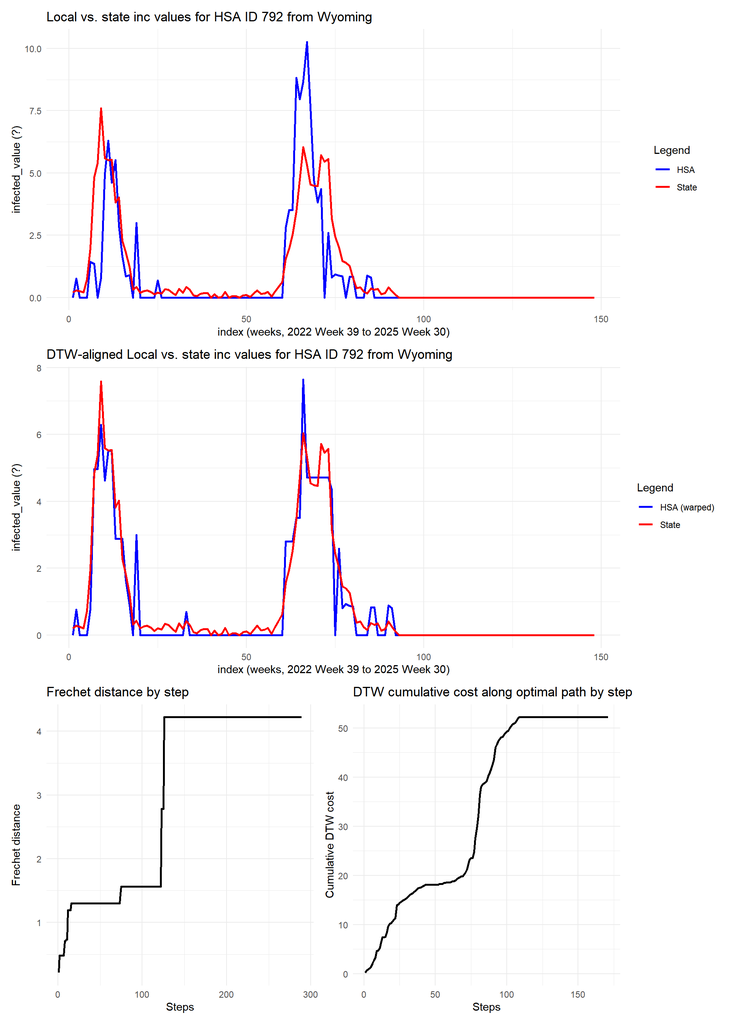

```r
# set.seed(77)
id_list = hsa_state$hsa_nci_id
id = sample(id_list, 1)
graph_hsa(hsa_id = id)
```

```r
dtw_stats(hsa_id = id)
```

| Metric | Value |
| --- | --- |
| mean_abs_lag | 1.895 |
| signed_lag | 1.556 |
| lag_sd | 2.822 |
| dtw_mae | 0.305 |
| dtw_rmse | 0.655 |
| rmse | 1.284 |
| amp_ratio | 0.000 |
| lag_amp_corr | 0.047 |

## Metric explanations

- Mean absolute lag is the average absolute time shift between matched points (points in P are aligned with points in Q about this many steps away)
- Mean lag but this time it is signed and that means it is usually smaller and portrays more accurately what an average time step would do
- Standard deviation of the time lag
- Mean absolute error along the DTW-warped path (how well shapes match)
- Root mean squared error along the DTW-warped path (penalizes larger differences more than the MAE)
- Root mean squared error along the regular path (for comparison)
- Median ratio of amplitudes along DTW-warped path (how much percent amplitude HSA is of state)
- Correlation between absolute lag and absolute amplitude difference along DTW-warped path (negative means large lag small amplitude together, positive is opposite), sees if these variables are related for this HSA ID

# Conclusion

Shannon entropy didn’t really have anything interesting related to these models and this sort of question so I couldn’t really find anything. I didn’t have time to get around to FluSight models this week because I was messing around with DTW but I’ll check it out next week.

DTW looks really good here and these metrics seem to be a good solution for the questions you had earlier regarding comparing these two curves.